```python
# importing the libraries

import pandas as pd
import seaborn as sns
import numpy as np
import matplotlib.pyplot as plt
from sklearn.metrics import confusion_matrix
from sklearn.model_selection import train_test_split, GridSearchCV, StratifiedKFold
from sklearn.metrics import accuracy_score, precision_score, recall_score, f1_score
from sklearn.metrics import confusion_matrix, roc_auc_score, mean_absolute_error, mean_squared_error
import xgboost as xgb
from sklearn.preprocessing import RobustScaler
import scipy.stats as stats
```

# Importing and splitting the data into training and testing

```python
# importing the file with the combined data of both the hospitals and splitting it into 2 parts

combined = pd.read_csv('./physionet_data.csv')

rows_to_drop = combined.loc[combined['Patient_ID'].apply(lambda x: len(str(x)) == 6)]
df_train = combined.drop(rows_to_drop.index)
df_train.to_csv('data_part1.csv', index=False)

rows_to_drop = combined.loc[combined['Patient_ID'].apply(lambda x: len(str(x)) != 6)]
df_test = combined.drop(rows_to_drop.index)
df_test.to_csv('data_part2.csv', index=False)

# check row counts after split
total_rows = len(combined)
train_rows = len(df_train)
test_rows = len(df_test)

print(f"Total rows: {total_rows}")
print(f"Train rows (Patient_ID length != 6): {train_rows} ({train_rows/total_rows*100:.2f}%)")
print(f"Test rows  (Patient_ID length == 6): {test_rows} ({test_rows/total_rows*100:.2f}%)")
```

```
Total rows: 1552210
Train rows (Patient_ID length != 6): 790215 (50.91%)
Test rows  (Patient_ID length == 6): 761995 (49.09%)
```

# Exploratory data analysis

# Training Dataset

```python
df_train.head(15)
```

|  | Unnamed: 0 | Hour | HR | O2Sat | Temp | SBP | MAP | DBP | Resp | EtCO2 | ... | Fibrinogen | Platelets | Age | Gender | Unit1 | Unit2 | HospAdmTime | ICULOS | SepsisLabel | Patient_ID |
| --- | --- | --- | --- | --- | --- | --- | --- | --- | --- | --- | --- | --- | --- | --- | --- | --- | --- | --- | --- | --- | --- |
| 0 | 0 | 0 | NaN | NaN | NaN | NaN | NaN | NaN | NaN | NaN | ... | NaN | NaN | 68.54 | 0 | NaN | NaN | -0.02 | 1 | 0 | 17072 |
| 1 | 1 | 1 | 65.0 | 100.0 | NaN | NaN | 72.0 | NaN | 16.5 | NaN | ... | NaN | NaN | 68.54 | 0 | NaN | NaN | -0.02 | 2 | 0 | 17072 |
| 2 | 2 | 2 | 78.0 | 100.0 | NaN | NaN | 42.5 | NaN | NaN | NaN | ... | NaN | NaN | 68.54 | 0 | NaN | NaN | -0.02 | 3 | 0 | 17072 |
| 3 | 3 | 3 | 73.0 | 100.0 | NaN | NaN | NaN | NaN | 17.0 | NaN | ... | NaN | NaN | 68.54 | 0 | NaN | NaN | -0.02 | 4 | 0 | 17072 |
| 4 | 4 | 4 | 70.0 | 100.0 | NaN | 129.0 | 74.0 | 69.0 | 14.0 | NaN | ... | NaN | 330.0 | 68.54 | 0 | NaN | NaN | -0.02 | 5 | 0 | 17072 |
| 5 | 5 | 5 | 62.0 | 100.0 | NaN | 124.0 | 85.0 | 61.0 | 14.0 | NaN | ... | NaN | NaN | 68.54 | 0 | NaN | NaN | -0.02 | 6 | 0 | 17072 |
| 6 | 6 | 6 | 61.0 | 100.0 | NaN | 101.0 | 75.0 | 58.0 | 14.0 | NaN | ... | NaN | NaN | 68.54 | 0 | NaN | NaN | -0.02 | 7 | 0 | 17072 |
| 7 | 7 | 7 | 68.0 | 100.0 | 35.78 | 142.0 | 93.5 | 78.0 | 16.0 | NaN | ... | NaN | NaN | 68.54 | 0 | NaN | NaN | -0.02 | 8 | 0 | 17072 |
| 8 | 8 | 8 | 71.0 | 100.0 | NaN | 121.0 | 74.0 | 91.0 | 14.0 | NaN | ... | NaN | NaN | 68.54 | 0 | NaN | NaN | -0.02 | 9 | 0 | 17072 |
| 9 | 9 | 9 | 69.0 | 100.0 | NaN | 120.0 | 79.0 | 98.0 | 14.0 | NaN | ... | NaN | NaN | 68.54 | 0 | NaN | NaN | -0.02 | 10 | 0 | 17072 |
| 10 | 10 | 10 | 75.0 | 100.0 | NaN | 146.0 | 93.0 | 67.0 | 14.0 | NaN | ... | NaN | NaN | 68.54 | 0 | NaN | NaN | -0.02 | 11 | 0 | 17072 |
| 11 | 11 | 11 | 84.0 | 100.0 | 36.39 | 128.0 | 80.0 | 60.0 | 14.0 | NaN | ... | NaN | NaN | 68.54 | 0 | NaN | NaN | -0.02 | 12 | 0 | 17072 |
| 12 | 12 | 12 | 85.0 | 100.0 | NaN | 124.0 | 79.0 | 59.0 | 14.0 | NaN | ... | NaN | NaN | 68.54 | 0 | NaN | NaN | -0.02 | 13 | 0 | 17072 |
| 13 | 13 | 13 | 85.0 | 100.0 | NaN | 141.0 | 95.0 | 69.0 | 14.0 | NaN | ... | NaN | 303.0 | 68.54 | 0 | NaN | NaN | -0.02 | 14 | 0 | 17072 |
| 14 | 14 | 14 | 89.0 | 100.0 | NaN | 117.0 | 86.0 | 68.0 | 14.0 | NaN | ... | NaN | NaN | 68.54 | 0 | NaN | NaN | -0.02 | 15 | 0 | 17072 |

15 rows × 44 columns

As can be seen, this is a time series data. The dataframe has 44 columns. After the first loook at data, it can be observed that the data seems quite sparse.

```python
# let's list down all the different columns
df_train.columns
```

```
Index(['Unnamed: 0', 'Hour', 'HR', 'O2Sat', 'Temp', 'SBP', 'MAP', 'DBP',
       'Resp', 'EtCO2', 'BaseExcess', 'HCO3', 'FiO2', 'pH', 'PaCO2', 'SaO2',
       'AST', 'BUN', 'Alkalinephos', 'Calcium', 'Chloride', 'Creatinine',
       'Bilirubin_direct', 'Glucose', 'Lactate', 'Magnesium', 'Phosphate',
       'Potassium', 'Bilirubin_total', 'TroponinI', 'Hct', 'Hgb', 'PTT', 'WBC',
       'Fibrinogen', 'Platelets', 'Age', 'Gender', 'Unit1', 'Unit2',
       'HospAdmTime', 'ICULOS', 'SepsisLabel', 'Patient_ID'],
      dtype='str')
```

```python
# list of all the unique patients
# total number of patients present in the dataset

patients = list(df_train['Patient_ID'].unique())
len(patients)
```

```
20336
```

```python
# Function to draw correlation heat map

def corr_matrix(df):
  corr = df.corr()
  mask = np.triu(np.ones_like(corr, dtype=bool))
  f, ax = plt.subplots(figsize=(40,40))
  cmap = sns.diverging_palette(220, 10, as_cmap=True)
  sns.heatmap(corr, mask=mask, cmap="Paired", vmax=.3, center=0,
              square=True, linewidths=.5, cbar_kws={"shrink": .5})
```

```python
# Percentage of null values present in all the parameters

null_values = df_train.isnull().mean()*100
null_values = null_values.sort_values(ascending=False)
null_values
```

```
EtCO2               100.000000
TroponinI            99.877881
Bilirubin_direct     99.850420
Fibrinogen           99.236917
Bilirubin_total      98.773372
Alkalinephos         98.540650
AST                  98.504205
Lactate              96.565112
PTT                  95.152459
SaO2                 95.044387
Calcium              95.024392
Phosphate            94.951247
Platelets            93.482913
Creatinine           93.357884
WBC                  92.489639
Magnesium            92.219712
HCO3                 91.949406
BUN                  91.840702
Chloride             91.676063
PaCO2                91.231753
Hgb                  91.164303
BaseExcess           89.574863
Potassium            89.137640
pH                   88.532868
Hct                  88.223711
Glucose              87.768392
FiO2                 85.807027
Temp                 66.224255
Unit2                48.868346
Unit1                48.868346
DBP                  48.125763
SBP                  15.211177
O2Sat                12.032042
MAP                  10.232405
Resp                  9.776833
HR                    7.743336
HospAdmTime           0.001012
Unnamed: 0            0.000000
Hour                  0.000000
Gender                0.000000
Age                   0.000000
ICULOS                0.000000
SepsisLabel           0.000000
Patient_ID            0.000000
dtype: float64
```

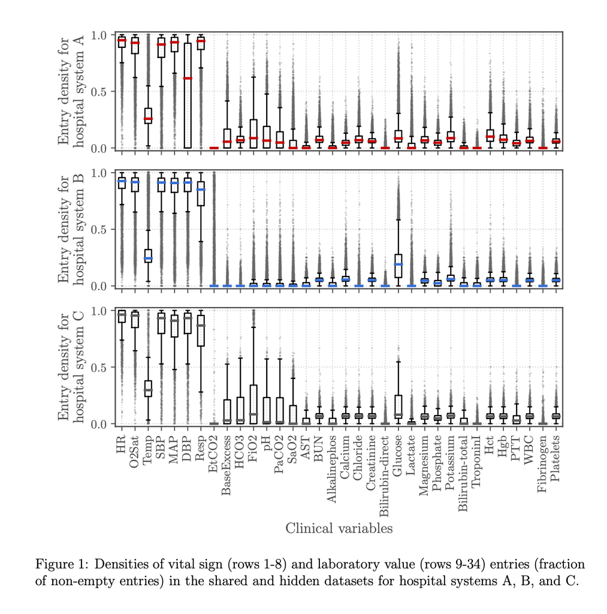

Image obtained from the official pdf of the PhysioNet Challenge. The image gives an overall idea of the number of records available for each feature, for all the three datasets of three different hospitals.

```python
# the features have been removed based to match the target domain dataset

columns_drop={'Unnamed: 0','EtCO2','BaseExcess', 'HCO3','Alkalinephos','Fibrinogen','Unit1','Unit2', 'Platelets', 'AST', 'HospAdmTime','Unit1', 'Unit2'}
df_train_mod = df_train.drop(columns=columns_drop)
df_train_mod.columns
```

```
Index(['Hour', 'HR', 'O2Sat', 'Temp', 'SBP', 'MAP', 'DBP', 'Resp', 'FiO2',
       'pH', 'PaCO2', 'SaO2', 'BUN', 'Calcium', 'Chloride', 'Creatinine',
       'Bilirubin_direct', 'Glucose', 'Lactate', 'Magnesium', 'Phosphate',
       'Potassium', 'Bilirubin_total', 'TroponinI', 'Hct', 'Hgb', 'PTT', 'WBC',
       'Age', 'Gender', 'ICULOS', 'SepsisLabel', 'Patient_ID'],
      dtype='str')
```

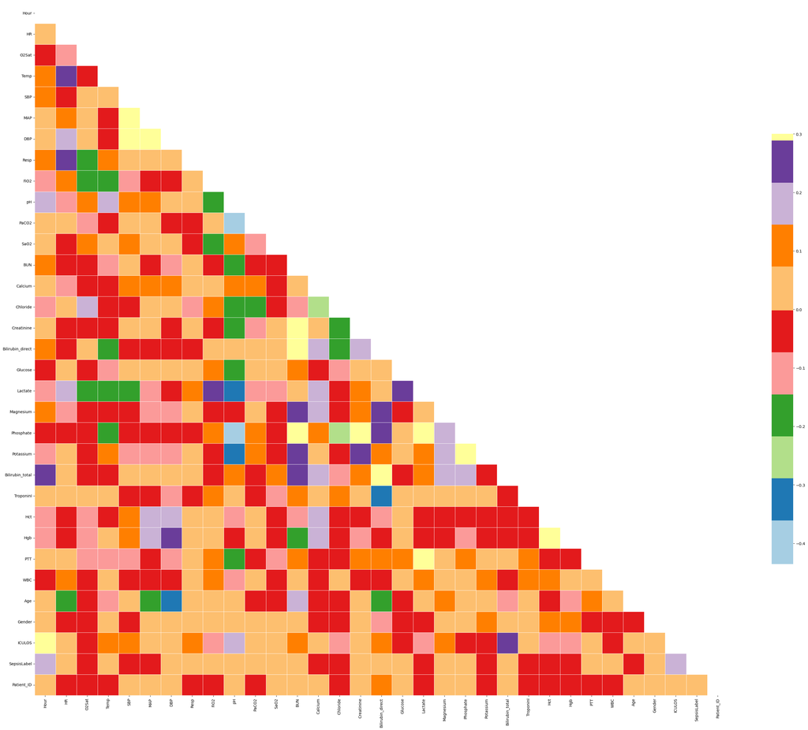

```python
# correlation matrix to check if there is high correlation between the remaining features

corr_matrix(df_train_mod)
```

As can be seen in this correlation heat map almost all of the feature do not have high correlation.